# Projekt_Analiza_Obrazków

Published

## Wprowadzenie do projektu

Celem tego projektu jest opracowanie modeli do klasyfikacji rodzajów ryżu na podstawie zdjęć. W projekcie wykorzystano zbiór danych Rice Image Dataset dostępny na platformie Kaggle. Cały proces analizy i budowy projektu został przeprowadzony w środowisku Kaggle. Projekt ten ma na celu automatyczne rozpoznawanie i klasyfikowanie zdjęć różnych gatunków ryżu, co może być przydatne w automatyzacji procesów w branży rolniczej i spożywczej.

## Link do projektu w Kaggle

https://www.kaggle.com/anastasiiaivas/projekt

## Używane biblioteki

Do realizacji projektu niezbędne były następujące biblioteki:

- `keras`
- `tidyverse`
- `tensorflow`
- `imager`

## Sprawdzenie liczby i nazw klas

W pierwszym kroku zidentyfikowano nazwy i liczbę klas w zbiorze danych. W zestawie danych znajdują się pięć następujących klas ryżu:

- Arborio

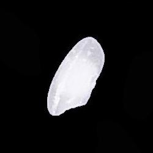

- Basmati

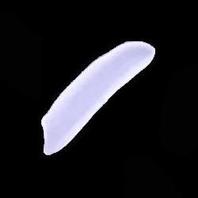

- Ipsala

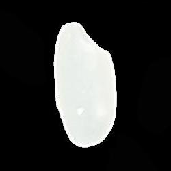

- Jasmine

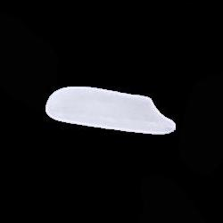

- Karacadag

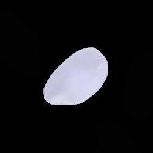

## Sprawdzenie liczebności zdjęć w każdej klasie

Następnie przeanalizowano liczebność zdjęć w każdej kategorii. Okazało się, że każda z pięciu klas zawiera dokładnie po 15000 zdjęć, co daje łącznie 75000 obrazów w całym zbiorze.

Ponieważ łączna liczba zdjęć jest bardzo duża, planowane jest zmniejszenie liczby obrazów w każdej klasie do 4000. Taka redukcja pozwoli na szybsze trenowanie modelu, zachowując jednocześnie wystarczającą liczbę danych do efektywnego nauczania.

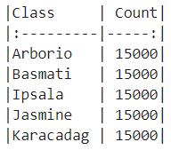

## Weryfikacja liczby zdjęć po losowym wyborze

Po losowym wybraniu zdjęć dla każdej grupy, sprawdzono, czy nowy zbiór rzeczywiście zawiera 4000 zdjęć dla każdej klasy. Wyniki tej weryfikacji pokazano w tabeli

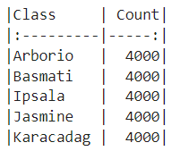

## Podział danych na zbiory treningowy, walidacyjny i testowy

Dane zostały podzielone na trzy zbiory: treningowy (70%), walidacyjny (15%) i testowy (15%). Stosowany jest podział warstwowy w celu zapewnienia, że proporcje poszczególnych klas są zachowane w każdym z tych zbiorów. Proces ten obejmował:

- Wylosowanie indeksów dla każdego ze zbiorów.
- Utworzenie odpowiednich katalogów dla danych treningowych, walidacyjnych i testowych.
- Skopiowanie odpowiednich plików do tych katalogów.

## Sprawdzenie liczby zdjęć w każdym z trzech zbiorów

Po podziale danych, liczba zdjęć dla każdej kategorii w zbiorach treningowym, walidacyjnym i testowym została sprawdzona. Wyniki są następujące:

- Zbiór treningowy: 2800 zdjęć dla każdej klasy.

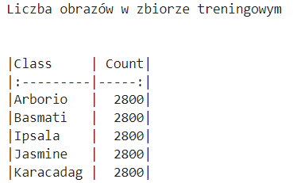

- Zbiór walidacyjny: 600 zdjęć dla każdej klasy.

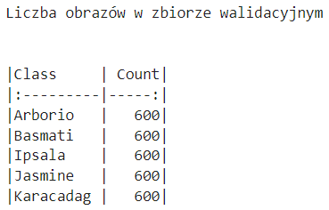

- Zbiór testowy: 600 zdjęć dla każdej klasy.

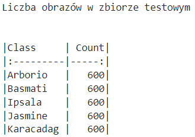

## Wizualizacja przykładowych obrazów z danych treningowych

Aby zwizualizować przykładowe obrazy ze zbioru treningowego, wybrano losowo 16 obrazów.

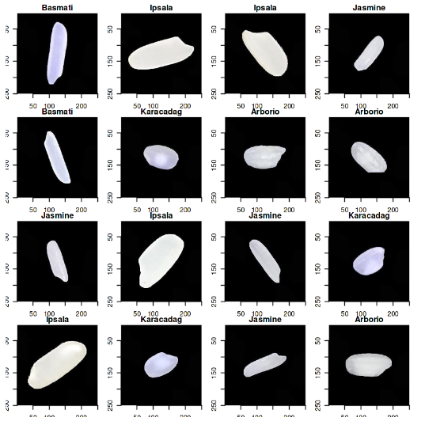

## Przygotowanie generatorów danych

Aby przygotować dane do trenowania modelu, użyto generatorów danych. Generatory te przekształcają obrazy w formacie surowym do odpowiedniego formatu wejściowego dla modelu sieci neuronowych.

- **Normalizacja obrazów**: Przeskalowanie wartości pikseli obrazów do zakresu [0, 1] przy użyciu `image_data_generator(rescale = 1/255)`.
- **Utworzenie generatorów danych**:
  - **Generatory dla wszystkich zbiorów zawierały następujące kroki**:
    - Wczytywanie obrazów z katalogu (“`train`”, “`val`” lub “`test`)”.
    - Losowe mieszanie obrazów (`shuffle = TRUE`).
    - Skalowanie obrazów do rozmiaru 150x150 pikseli.
    - Przetwarzanie danych w partiach po 32 obrazy.
    - Ustawienie trybu klasyfikacji na “categorical” dla klasyfikacji wieloklasowej.

# Modelowanie

W tej części projektu przedstawione zostaną różne modele sieci neuronowych. Następnie ich wydajność zostanie porównana, aby wybrać najlepszy model.

## 1. Prosta Konwolucyjna Sieć Neuronowa z Warstwą Dropout

Zbudowano prostą konwolucyjną sieć neuronową z warstwą dropout, aby zapobiec przeuczeniu się modelu.

```r
baza1 <- layer_conv_2d(filters = 32, kernel_size = 3, padding = 'valid', activation = 'relu', input_shape = c(150, 150, 3))

model <- keras_model_sequential() %>%
baza1 %>%
  layer_max_pooling_2d(pool_size = 2, strides = 2) %>%
  layer_flatten() %>%
  layer_dense(units = 45, activation = 'relu') %>%
  layer_dense(units = 15, activation = 'relu') %>%
  layer_dropout(rate = 0.1, seed = 100) %>%
  layer_dense(units = 5, activation = 'sigmoid')

model %>% compile(
  optimizer = optimizer_adam(),
  loss = 'categorical_crossentropy',
  metrics = c('accuracy')
)

summary(model)
```

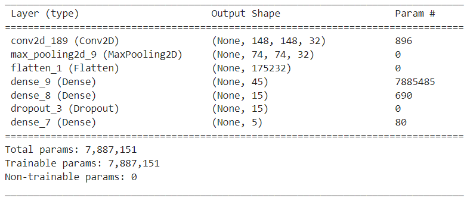

Model został wytrenowany na danych treningowych przez 30 epok. Wyniki były weryfikowane na zbiorze walidacyjnym w każdej epoce. Dla każdego kolejnego modelu proces trenowania będzie przebiegał w ten sam sposób.

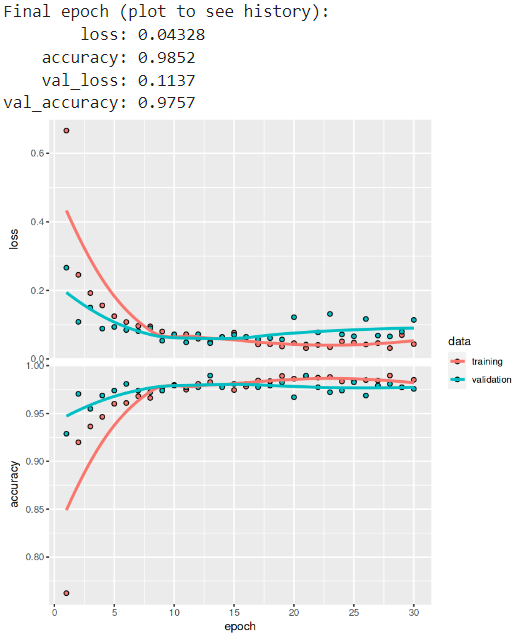

```r
history <- model %>% fit(
  train_generator,
  steps_per_epoch = length(train_indices) %/% 32,
  epochs = 30,
  validation_data = val_generator,
  validation_steps = length(val_indices) %/% 32
)

history
plot(history)
```

- Wysokie wartości dokładności oraz niskie wartości strat zarówno dla zbioru treningowego, jak i walidacyjnego, sugerują, że model jest skuteczny w klasyfikacji obrazów.
- Brak znaczącej różnicy między wynikami na zbiorze treningowym i walidacyjnym wskazuje, że model nie jest mocno przeuczony. Model dobrze generalizuje, co oznacza, że jego wydajność na danych, które nie były używane podczas treningu, jest równie dobra jak na danych treningowych.

#### Accuracy dla zbioru treningowego, walidacyjnego i testowego

Wartość accuracy na zbiorze testowym wynosi **0.971**, co oznacza, że model poprawnie klasyfikuje 97,1% obrazów z danych testowych.

#### Loss dla zbioru treningowego, walidacyjnego i testowego

Wartość straty na zbiorze testowym wynosi **0.094**, co wskazuje na niewielki błąd predykcji modelu na danych testowych.

#### Wnioski

Model Prostej Konwolucyjnej Sieci Neuronowej z Warstwą Dropout został skutecznie wytrenowany na danych treningowych i osiągnął wysoką dokładność zarówno na zbiorze treningowym, jak i walidacyjnym.

Podsumowując, Prosta Konwolucyjna Sieć Neuronowa z Warstwą Dropout bardzo dobrze radzi sobie z zadaniem klasyfikacji ryżu. Model jest skuteczny i wykazuje zdolność do prawidłowej klasyfikacji nowych, nieznanych danych.

### 2. InceptionV3 z Warstwą Dropout

Zbudowano model InceptionV3 z warstwą dropout, aby zapobiec przeuczeniu się modelu.

```r
baza2 <- application_inception_v3(weights = NULL, include_top = FALSE, input_shape = c(150, 150, 3))

model2 <- keras_model_sequential() %>%
  baza2 %>%
  layer_global_average_pooling_2d() %>%
  layer_dense(units = 1024, activation = 'relu') %>%
  layer_dropout(rate = 0.5) %>%
  layer_dense(units = 5, activation = 'softmax')

model2 %>% compile(
  optimizer = optimizer_adam(),
  loss = 'categorical_crossentropy',
  metrics = c('accuracy')
)
summary(model2)
```

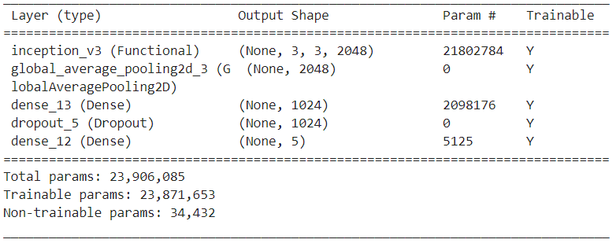

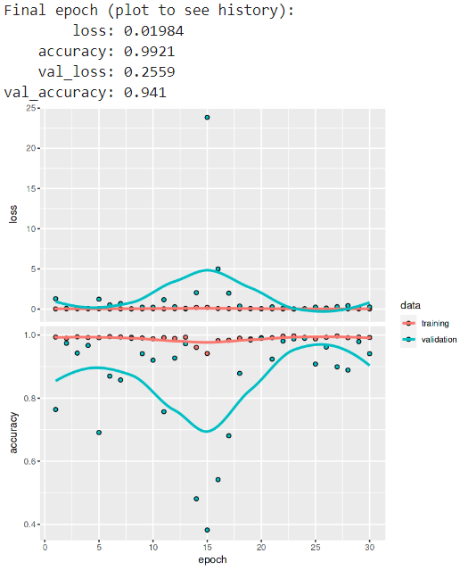

- Wysokie wartości dokładności oraz niskie wartości strat dla zbioru treningowego sugerują, że model skutecznie uczy się na danych treningowych.
- Znacząca różnica między wynikami na zbiorze treningowym i walidacyjnym wskazuje, że model może być przeuczony, ponieważ dokładność walidacyjna jest niższa niż treningowa, a strata walidacyjna jest wyższa niż treningowa.

#### Accuracy dla zbioru treningowego, walidacyjnego i testowego

Wartość accuracy na zbiorze testowym wynosi **0.941**, co oznacza, że model poprawnie klasyfikuje 94,1% obrazów z danych testowych.

#### Loss dla zbioru treningowego, walidacyjnego i testowego

Wartość straty na zbiorze testowym wynosi **0.243**, co wskazuje na umiarkowany błąd predykcji modelu na danych testowych.

#### Wnioski

Model InceptionV3 z Warstwą Dropout został wytrenowany na danych treningowych i osiągnął wysoką dokładność na zbiorze treningowym, lecz ma gorszą wydajność na danych, na których nie był uczony.

Podsumowując, model InceptionV3 z Warstwą Dropout dość dobrze radzi sobie z klasyfikacją, ale nie jest tak skuteczny jak wcześniejszy model prostej konwolucyjnej sieci neuronowej. Wydajność modelu InceptionV3 można spróbować poprawić poprzez dodanie większej liczby warstw oraz zastosowanie regularizacji L2, co może pomóc w lepszej generalizacji modelu na dane walidacyjne i testowe.

### 3. InceptionV3 z Wieloma Warstwami Dropout i Regularizacją L2

Zbudowano model InceptionV3 z wieloma warstwami dropout i regularizacją L2, aby zapobiec przeuczeniu się modelu oraz poprawić jego wydajność.

```r
baza3 <- application_inception_v3(weights = NULL, include_top = FALSE, input_shape = c(150, 150, 3))

model3 <- keras_model_sequential() %>%
  baza3 %>%
  layer_global_average_pooling_2d() %>%
  layer_dense(units = 1500, activation = 'relu', kernel_regularizer = regularizer_l2(0.001)) %>%
  layer_dropout(rate = 0.5) %>%
  layer_dense(units = 700, activation = 'relu', kernel_regularizer = regularizer_l2(0.001)) %>%
  layer_dropout(rate = 0.5) %>%
  layer_dense(units = 300, activation = 'relu', kernel_regularizer = regularizer_l2(0.001)) %>%
  layer_dropout(rate = 0.5) %>%
  layer_dense(units = 100, activation = 'relu', kernel_regularizer = regularizer_l2(0.001)) %>%
  layer_dropout(rate = 0.5) %>%
  layer_dense(units = 5, activation = 'softmax')

model3 %>% compile(
  optimizer = optimizer_adam(),
  loss = 'categorical_crossentropy',
  metrics = c('accuracy')
)
summary(model3)
```

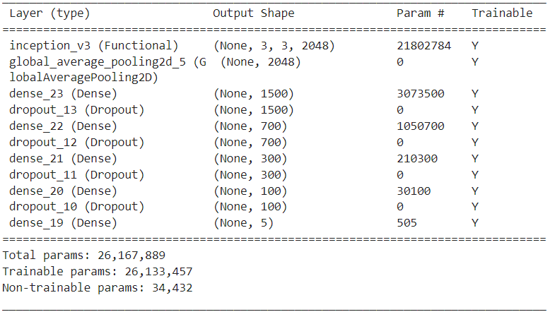

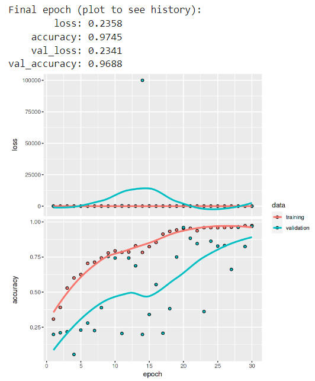

- Wysokie wartości dokładności oraz niskie wartości strat dla zbioru treningowego sugerują, że model skutecznie uczy się na danych treningowych.
- Mniejsza różnica między wynikami na zbiorze treningowym i walidacyjnym w porównaniu do poprzedniego modelu wskazuje, że model lepiej generalizuje i jest mniej podatny na przeuczenie. Model osiąga wysoką dokładność i umiarkowaną stratę na zbiorze walidacyjnym, co oznacza, że jego wydajność na danych, które nie były używane podczas treningu, jest dobra.

#### Accuracy dla zbioru treningowego, walidacyjnego i testowego

Wartość accuracy na zbiorze testowym wynosi **0.966**, co oznacza, że model poprawnie klasyfikuje 96,6% obrazów z danych testowych.

#### Loss dla zbioru treningowego, walidacyjnego i testowego

Wartość straty na zbiorze testowym wynosi **0.241**, co wskazuje na umiarkowany błąd predykcji modelu na danych testowych.

#### Wnioski

Model InceptionV3 z Wieloma Warstwami Dropout i Regularizacją L2 został wytrenowany na danych treningowych i osiągnął wysoką dokładność na zbiorze treningowym oraz dobrą wydajność na danych, na których nie był uczony.

Podsumowując, model poprawił dokładność w porównaniu do poprzedniego modelu. Różnice między wartościami dokładności na zbiorze treningowym a testowym są mniejsze, co wskazuje na lepszą generalizację. Można zauważyć, że dodanie większej liczby warstw i zastosowanie regularizacji L2 pomogło w lepszym dostosowaniu modelu do klasyfikacji danych walidacyjnych i testowych.

### 4. ResNet50 z Wieloma Warstwami Dropout i Regularizacją L2

Zbudowano model ResNet50 z wieloma warstwami dropout i regularizacją L2, aby zapobiec przeuczeniu się modelu oraz poprawić jego wydajność.

```r
baza4 <- application_resnet50(weights = NULL, include_top = FALSE, input_shape = c(150, 150, 3))

model4 <- keras_model_sequential() %>%
  baza4 %>%
  layer_global_average_pooling_2d() %>%
  layer_dense(units = 2000, activation = 'relu', kernel_regularizer = regularizer_l2(0.001)) %>%
  layer_dropout(rate = 0.5) %>%
  layer_dense(units = 500, activation = 'relu', kernel_regularizer = regularizer_l2(0.001)) %>%
  layer_dropout(rate = 0.5) %>%
  layer_dense(units = 5, activation = 'softmax')

model4 %>% compile(
  optimizer = optimizer_adam(),
  loss = 'categorical_crossentropy',
  metrics = c('accuracy')
)

summary(model4)
```

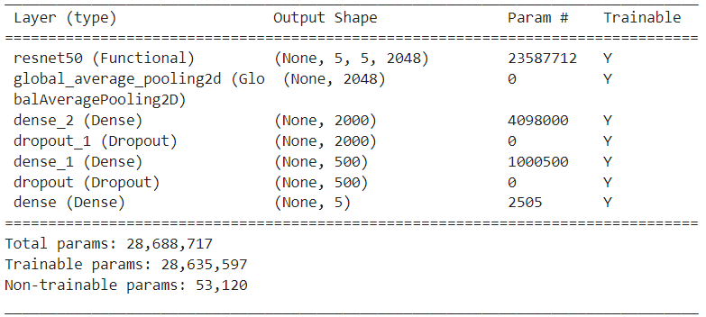

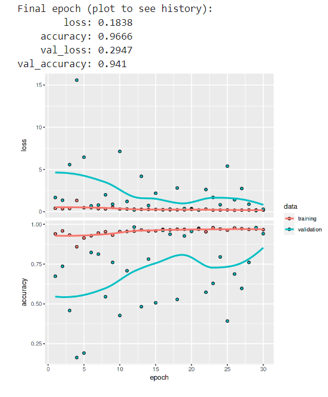

- Wysokie wartości dokładności oraz niskie wartości strat dla zbioru treningowego sugerują, że model skutecznie uczy się na danych treningowych.
- Różnica między wynikami na zbiorze treningowym i walidacyjnym wskazuje, że model może być przeuczony. Różnice nie są bardzo duże, ale dokładność walidacyjna jest niższa niż treningowa, a strata walidacyjna jest wyższa niż treningowa.

#### Accuracy dla zbioru treningowego, walidacyjnego i testowego

Wartość accuracy na zbiorze testowym wynosi **0.961**, co oznacza, że model poprawnie klasyfikuje 96,1% obrazów z danych testowych.

#### Loss dla zbioru treningowego, walidacyjnego i testowego

Wartość straty na zbiorze testowym wynosi **0.206**, co wskazuje na umiarkowany błąd predykcji modelu na danych testowych.

#### Wnioski

Model ResNet50 z Wieloma Warstwami Dropout i Regularizacją L2 został wytrenowany na danych treningowych i osiągnął wysoką dokładność na zbiorze treningowym, lecz jego wydajność na danych walidacyjnych i testowych wskazuje na możliwość przeuczenia.

Podsumowując, model ResNet50 z wieloma warstwami dropout i regularizacją L2 dobrze radzi sobie z klasyfikacją, osiągając wysoką dokładność na zbiorze testowym. Jednak wydajność dla tego modelu jest trochę gorsza od pierwszego i trzeciego modelu.

### 5. Xception z Wieloma Warstwami Dropout i Regularizacją L2

Zbudowano model Xception z wieloma warstwami dropout i regularizacją L2, aby zapobiec przeuczeniu się modelu oraz poprawić jego wydajność.

[figure not shown]

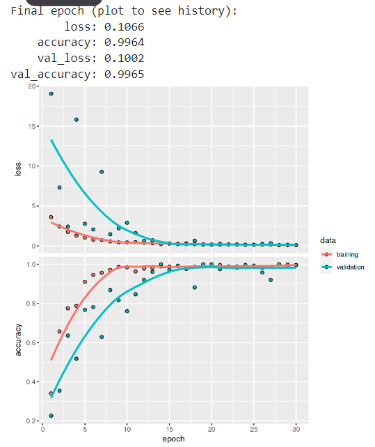

```r
baza5 <- application_xception(weights = "imagenet", include_top = FALSE, input_shape = c(150, 150, 3))

model5 <- keras_model_sequential() %>%
  baza5 %>%
  layer_global_average_pooling_2d() %>%
  layer_dense(units = 1024, activation = 'relu', kernel_regularizer = regularizer_l2(0.001)) %>%
  layer_dropout(rate = 0.5) %>%
  layer_dense(units = 512, activation = 'relu', kernel_regularizer = regularizer_l2(0.001)) %>%
  layer_dropout(rate = 0.5) %>%
  layer_dense(units = 256, activation = 'relu', kernel_regularizer = regularizer_l2(0.001)) %>%
  layer_dropout(rate = 0.5) %>%
  layer_dense(units = 128, activation = 'relu', kernel_regularizer = regularizer_l2(0.001)) %>%
  layer_dropout(rate = 0.5) %>%
  layer_dense(units = 5, activation = 'softmax')

model5 %>% compile(
  optimizer = optimizer_adam(),
  loss = 'categorical_crossentropy',
  metrics = c('accuracy')
)

summary(model5)
```

- Wysokie wartości dokładności oraz niskie wartości strat dla zbioru treningowego sugerują, że model skutecznie uczy się na danych treningowych.
- Mała różnica między wynikami na zbiorze treningowym i walidacyjnym w porównaniu do poprzedniego modelu wskazuje, że model lepiej generalizuje i jest mniej podatny na przeuczenie. Model osiąga wysoką dokładność i dość niską wartość straty na zbiorze walidacyjnym, co oznacza, że jego wydajność na danych, które nie były używane podczas treningu, jest bardzo dobra.

#### Accuracy dla zbioru treningowego, walidacyjnego i testowego

Wartość accuracy na zbiorze testowym wynosi **0.998**, co oznacza, że model poprawnie klasyfikuje 99,8% obrazów z danych testowych.

#### Loss dla zbioru treningowego, walidacyjnego i testowego

Wartość straty na zbiorze testowym wynosi **0.094**, co wskazuje na niewielki błąd predykcji modelu na danych testowych.

#### Wnioski

Model Xception z Wieloma Warstwami Dropout i Regularizacją L2 został wytrenowany na danych treningowych i osiągnął wysoką dokładność na zbiorze treningowym oraz dobrą wydajność na danych, na których nie był uczony.

Podsumowując, model Xception z wieloma warstwami dropout i regularizacją L2 poprawił dokładność w porównaniu do poprzednich modeli. Różnice między wartościami dokładności na zbiorze treningowym a testowym są mmałe, co wskazuje na lepszą generalizację. Ten model bardzo dobrze sobie radzi z zaganiem klasyfikacji rodzai ryżu.

### 6. Advanced AlexNet z Wieloma Warstwami Dropout i Regularizacją L2

Zbudowano model Advanced AlexNet z wieloma warstwami dropout i regularizacją L2, aby zapobiec przeuczeniu się modelu oraz poprawić jego wydajność.

```r
baza6 <- keras_model_sequential() %>%
  layer_conv_2d(filters = 96, kernel_size = c(11, 11), strides = c(4, 4), activation = 'relu', input_shape = c(150, 150, 3)) %>%
  layer_max_pooling_2d(pool_size = c(3, 3), strides = c(2, 2)) %>%
  layer_conv_2d(filters = 256, kernel_size = c(5, 5), padding = 'same', activation = 'relu') %>%
  layer_max_pooling_2d(pool_size = c(3, 3), strides = c(2, 2)) %>%
  layer_conv_2d(filters = 384, kernel_size = c(3, 3), padding = 'same', activation = 'relu') %>%
  layer_conv_2d(filters = 384, kernel_size = c(3, 3), padding = 'same', activation = 'relu') %>%
  layer_conv_2d(filters = 256, kernel_size = c(3, 3), padding = 'same', activation = 'relu') %>%
  layer_max_pooling_2d(pool_size = c(3, 3), strides = c(2, 2))

model6 <- keras_model_sequential() %>%
  baza6 %>%
  layer_global_average_pooling_2d() %>%
  layer_dense(units = 3000, activation = 'relu', kernel_regularizer = regularizer_l2(0.001)) %>%
  layer_dropout(rate = 0.5) %>%
  layer_dense(units = 1000, activation = 'relu', kernel_regularizer = regularizer_l2(0.001)) %>%
  layer_dropout(rate = 0.5) %>%
  layer_dense(units = 550, activation = 'relu', kernel_regularizer = regularizer_l2(0.001)) %>%
  layer_dropout(rate = 0.5) %>%
  layer_dense(units = 100, activation = 'relu', kernel_regularizer = regularizer_l2(0.001)) %>%
  layer_dropout(rate = 0.5) %>%
  layer_dense(units = 5, activation = 'softmax')

model6 %>% compile(
  optimizer = optimizer_adam(),
  loss = 'categorical_crossentropy',
  metrics = c('accuracy')
)

summary(model6)
```

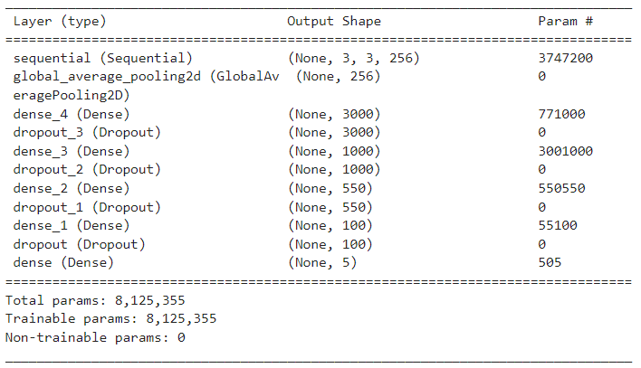

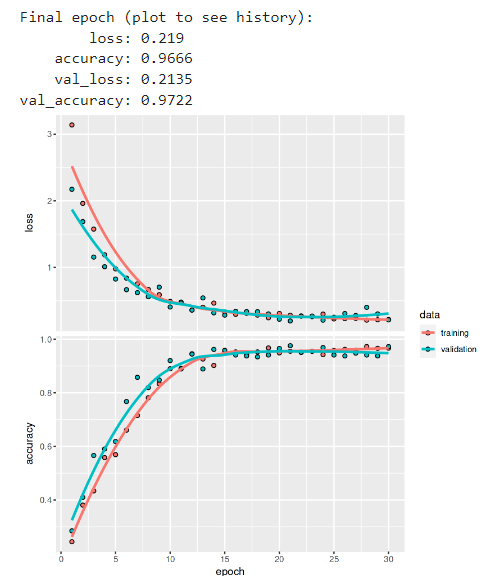

#### Accuracy dla zbioru treningowego, walidacyjnego i testowego

Wartość accuracy na zbiorze testowym wynosi **0.964**, co oznacza, że model poprawnie klasyfikuje 96,4% obrazów z danych testowych.

#### Loss dla zbioru treningowego, walidacyjnego i testowego

Wartość straty na zbiorze testowym wynosi **0.207**, co wskazuje na umiarkowany błąd predykcji modelu na danych testowych.

#### Wnioski

Model Advanced AlexNet z Wieloma Warstwami Dropout i Regularizacją L2 został wytrenowany na danych treningowych i osiągnął dość wysoką dokładność na zbiorze treningowym oraz dobrą wydajność na danych, na których nie był uczony.

Podsumowując, model wykazuje dobrą generalizację i umiarkowany błąd predykcji na zbiorze testowym, co oznacza, że model jest skuteczny w klasyfikacji obrazów. Można zauważyć, że dodanie większej liczby warstw i zastosowanie regularizacji L2 pomogło w lepszym dostosowaniu modelu do klasyfikacji danych walidacyjnych i testowych.

## Porównanie przewidywanych i rzeczywistych etykiet

Można ocenić, jak skutecznie model klasyfikuje nowe, nieznane dane, poprzez bezpośrednią wizualizację wyników. Przeprowadźmy taką analizę dla modelu 6. Na poniższych obrazkach można zobaczyć porównanie przewidywanych klas z rzeczywistymi klasami.

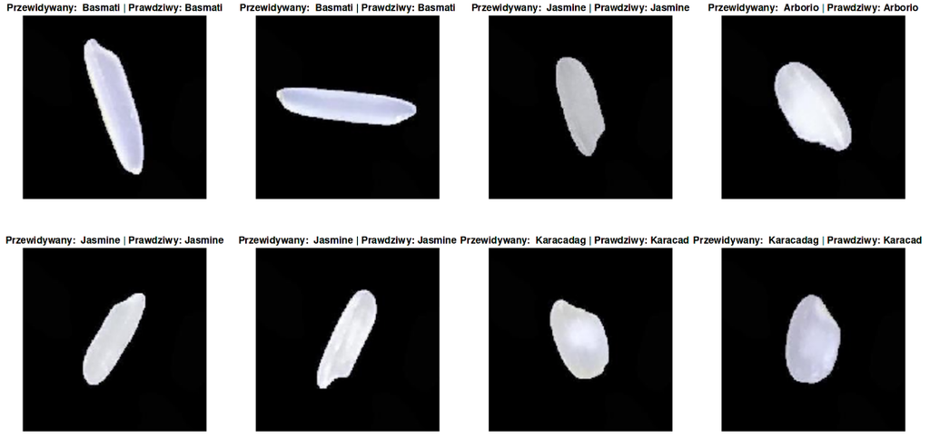

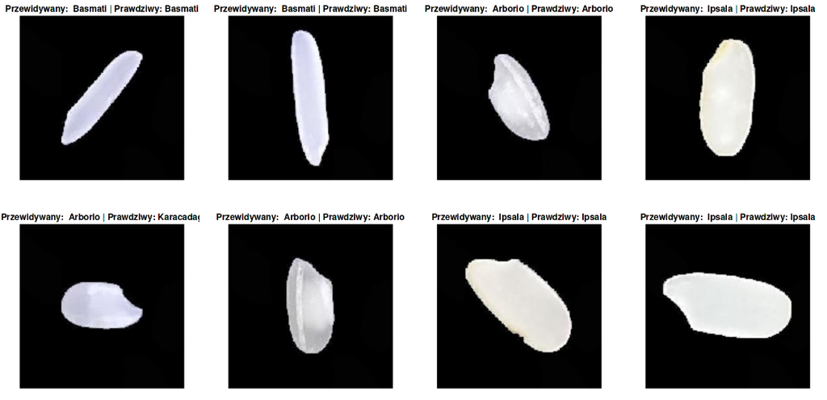

Jak widać, prawie wszystkie zdjęcia zostały zaklasyfikowane poprawnie.

## Porównywanie modeli

W ramach projektu zostały zbudowane i wytrenowane różne modele sieci neuronowych, mające na celu klasyfikację rodzajów ryżu na podstawie zdjęć. Modele te, choć wszystkie skutecznie radzą sobie z zadaniem, wykazują różnice w wydajności, które można zaobserwować w wartościach dokładności (accuracy) oraz straty (loss).

Aby dokładnie ocenić, który model jest najbardziej efektywny, konieczne jest porównanie ich wyników za pomocą wykresów.

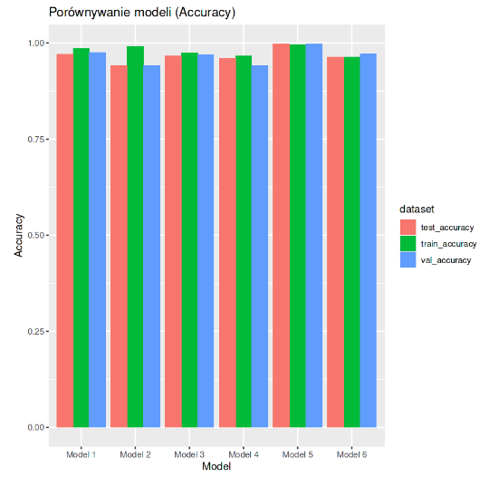

Udało się stworzyć kilka modeli, z których każdy osiąga dokładność powyżej 90%. Świadczy to o tym, że modele zostały dobrze dobrane, oraz optymalnie wybrana została liczba zdjęć dla każdej kategorii.

Mimo że wszystkie modele radzą sobie bardzo dobrze z zadaniem klasyfikacji obrazów ryżu, model piąty (Xception z Wieloma Warstwami Dropout i Regularizacją L2) wyróżnia się najwyższą dokładnością na zbiorze testowym. To pokazuje, że zastosowanie zaawansowanej architektury sieci neuronowej oraz odpowiednich technik regularizacji i warstw dropout skutkuje lepszym dostosowaniem modelu do danych testowych.

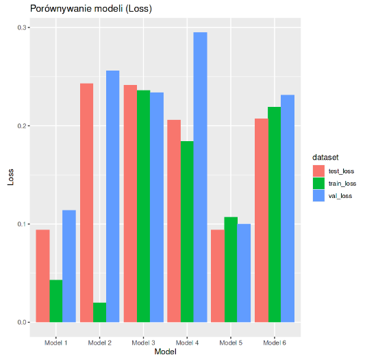

Wykres przedstawia porównanie strat (loss) dla różnych modeli na zbiorach treningowych, walidacyjnych i testowych.

Na wykresie można zauważyć, że modele 1 i 5 osiągają najniższą stratę na zbiorze testowym, co wskazuje na ich wysoką skuteczność w klasyfikacji obrazów ryżu. To oznacza, że te modele mają najmniejszy błąd predykcji na danych, na których nie były trenowane, co czyni te modele najlepszymi pod względem zdolności do generalizacji i precyzji klasyfikacji na tle innych modeli.

#### Wnioski

Na podstawie wyników dokładności (accuracy) i strat (loss) na zbiorach treningowych, walidacyjnych i testowych, model piąty (Xception z Wieloma Warstwami Dropout i Regularizacją L2) jest najlepszym modelem spośród wszystkich testowanych. Jego wysoka dokładność i niska strata na zbiorze testowym wskazują, że jest najlepiej dostosowany do klasyfikacji obrazów ryżu i generalizuje najskuteczniej na nowe, nieznane dane.